# Exploratory Data Analysis

```python
# 1. Mount Google Drive
from google.colab import drive
drive.mount('/content/drive')

# 2. Import Libraries for Data & Visuals
import pandas as pd
import numpy as np
import matplotlib.pyplot as plt
import seaborn as sns
import plotly.express as px
import plotly.graph_objects as go

# 3. Setting Visual Aesthetics
sns.set_theme(style="whitegrid", palette="muted")
plt.rcParams['figure.figsize'] = (12, 6)
plt.rcParams['font.size'] = 12
pd.set_option('display.max_columns', None) # Ensures we see all columns

#print("Libraries loaded and Drive mounted.")
```

```python
import os

#
# Example: '/content/drive/MyDrive/Airline_Project/'
folder_path = '/content/drive/MyDrive/'

# File names
pkl_file = os.path.join(folder_path, 'train_val.pkl')
csv_file = os.path.join(folder_path, 'train_val.csv')

# Loading the dataset (Prioritizing PKL for speed)
try:
    print(f"Attempting to load from: {pkl_file}")
    df = pd.read_pickle(pkl_file)
    print("Success: Data loaded from PKL file.")
except FileNotFoundError:
    print(f"PKL not found. Attempting to load from: {csv_file}")
    try:
        df = pd.read_csv(csv_file)
        print("Success: Data loaded from CSV file.")
    except FileNotFoundError:
        print("Error: Neither PKL nor CSV file found. Please check the path.")

# Quick check of the data
if 'df' in locals():
    print(f"Dataset Shape: {df.shape}")
    display(df.head(3))
    print(f"Column Data Types:\n{df.dtypes}")
```

```
Attempting to load from: /content/drive/MyDrive/train_val.pkl
Success: Data loaded from PKL file.
Dataset Shape: (7097476, 35)
```

|  | MONTH | DAY_OF_MONTH | DAY_OF_WEEK | TAIL_NUM | DEST_AIRPORT_ID | CRS_DEP_TIME | DEP_DEL15 | DEP_TIME_BLK | CRS_ARR_TIME | CRS_ELAPSED_TIME | DISTANCE | DISTANCE_GROUP | SEGMENT_NUMBER | CONCURRENT_FLIGHTS | DEP_HOUR | NUMBER_OF_SEATS | CARRIER_NAME | AIRPORT_FLIGHTS_MONTH | AIRLINE_FLIGHTS_MONTH | AIRLINE_AIRPORT_FLIGHTS_MONTH | AVG_MONTHLY_PASS_AIRPORT | AVG_MONTHLY_PASS_AIRLINE | FLT_ATTENDANTS_PER_PASS | GROUND_SERV_PER_PASS | PLANE_AGE | DEPARTING_AIRPORT | LATITUDE | LONGITUDE | PREVIOUS_AIRPORT | … |
| --- | --- | --- | --- | --- | --- | --- | --- | --- | --- | --- | --- | --- | --- | --- | --- | --- | --- | --- | --- | --- | --- | --- | --- | --- | --- | --- | --- | --- | --- | --- |
| 0 | 1 | 30 | 3 | N326NB | 11433 | 605.0 | 0 | 0600-0659 | 744 | 99.0 | 201.0 | 1 | 1 | 15.0 | 6 | 132 | Delta Air Lines Inc. | 3859 | 73508 | 287 | 385767 | 12460183 | 0.000144 | 0.000149 | 18 | Pittsburgh International | 40.497 | -80.236 | NONE | … |
| 1 | 1 | 30 | 3 | N776DE | 11433 | 910.0 | 0 | 0900-0959 | 1647 | 277.0 | 1979.0 | 8 | 1 | 34.0 | 9 | 160 | Delta Air Lines Inc. | 17725 | 73508 | 2896 | 2780593 | 12460183 | 0.000144 | 0.000149 | 6 | Los Angeles International | 33.942 | -118.408 | NONE | … |
| 2 | 1 | 30 | 3 | N892AT | 13487 | 815.0 | 0 | 0800-0859 | 1021 | 186.0 | 930.0 | 4 | 1 | 19.0 | 8 | 110 | Delta Air Lines Inc. | 18811 | 73508 | 534 | 2006675 | 12460183 | 0.000144 | 0.000149 | 15 | Douglas Municipal | 35.219 | -80.936 | NONE | … |

```
Column Data Types:
MONTH                                    object
DAY_OF_MONTH                              int64
DAY_OF_WEEK                              object
TAIL_NUM                                 object
DEST_AIRPORT_ID                          object
CRS_DEP_TIME                            float64
DEP_DEL15                                  int8
DEP_TIME_BLK                             object
CRS_ARR_TIME                             object
CRS_ELAPSED_TIME                        float64
DISTANCE                                float64
DISTANCE_GROUP                             int8
SEGMENT_NUMBER                            int64
CONCURRENT_FLIGHTS                      float64
DEP_HOUR                                   int8
NUMBER_OF_SEATS                           int16
CARRIER_NAME                             object
AIRPORT_FLIGHTS_MONTH                     int64
AIRLINE_FLIGHTS_MONTH                     int64
AIRLINE_AIRPORT_FLIGHTS_MONTH             int64
AVG_MONTHLY_PASS_AIRPORT                  int64
AVG_MONTHLY_PASS_AIRLINE                  int64
FLT_ATTENDANTS_PER_PASS                 float64
GROUND_SERV_PER_PASS                    float64
PLANE_AGE                                 int32
DEPARTING_AIRPORT                        object
LATITUDE                                float64
LONGITUDE                               float64
PREVIOUS_AIRPORT                         object
DATE                             datetime64[ns]
PRCP                                    float64
SNOW                                    float64
SNWD                                    float64
TMAX                                    float64
AWND                                    float64
dtype: object
```

### Note: We group by Day of Week and Hour, taking the MEAN of DEP_DEL15 (which gives us the % chance of delay)

## The "When" – Traffic & Delay Heatmap

Insight: Does the time of day or day of the week affect delays?

Visual: A heatmap showing the percentage of delays (DEP_DEL15) for every Day/Hour combination.

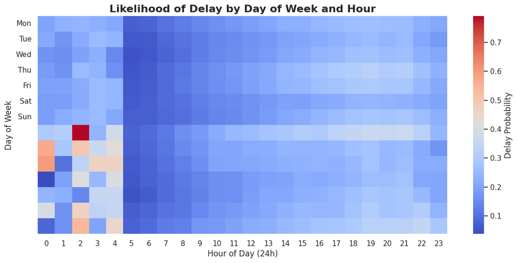

```python
# Create a pivot table for the Heatmap
# We group by Day of Week and Hour, taking the MEAN of DEP_DEL15 (which gives us the % chance of delay)
heatmap_data = df.groupby(['DAY_OF_WEEK', 'DEP_HOUR'])['DEP_DEL15'].mean().reset_index()
heatmap_data = heatmap_data.pivot(index='DAY_OF_WEEK', columns='DEP_HOUR', values='DEP_DEL15')

# Plotting
plt.figure(figsize=(14, 6))
sns.heatmap(heatmap_data, cmap="coolwarm", annot=False, fmt=".2f", cbar_kws={'label': 'Delay Probability'})
plt.title('Likelihood of Delay by Day of Week and Hour', fontsize=16, fontweight='bold')
plt.xlabel('Hour of Day (24h)', fontsize=12)
plt.ylabel('Day of Week', fontsize=12)
plt.yticks(ticks=[0.5, 1.5, 2.5, 3.5, 4.5, 5.5, 6.5],
           labels=['Mon', 'Tue', 'Wed', 'Thu', 'Fri', 'Sat', 'Sun'], rotation=0)
plt.show()
```

## The "Who" – Airline Comparison

Insight: Which airlines are the most reliable?

Visual: A ranked bar chart showing the delay rate per airline.

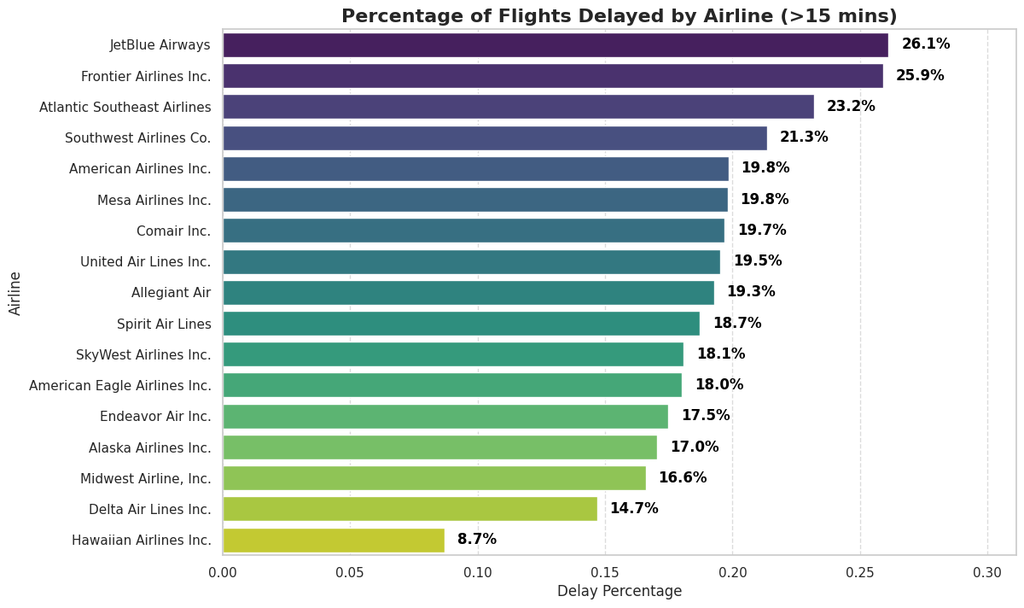

```python
# Aggregate delay rates by Carrier
carrier_delays = df.groupby('CARRIER_NAME')['DEP_DEL15'].agg(['mean', 'count']).reset_index()
carrier_delays = carrier_delays.sort_values(by='mean', ascending=False)

# Filter out very small carriers if necessary (optional, e.g., > 1000 flights)
carrier_delays = carrier_delays[carrier_delays['count'] > 1000]

# Plotting
plt.figure(figsize=(12, 8))
barplot = sns.barplot(data=carrier_delays, x='mean', y='CARRIER_NAME', palette="viridis")

# Add percentage labels to the bars for readability
for i, v in enumerate(carrier_delays['mean']):
    barplot.text(v + 0.005, i, f"{v:.1%}", color='black', va='center', fontweight='bold')

plt.title('Percentage of Flights Delayed by Airline (>15 mins)', fontsize=16, fontweight='bold')
plt.xlabel('Delay Percentage', fontsize=12)
plt.ylabel('Airline', fontsize=12)
plt.xlim(0, carrier_delays['mean'].max() + 0.05) # Add breathing room on the right
plt.grid(axis='x', linestyle='--', alpha=0.7)
plt.show()
```

## The "Why" – Impact of Plane Age

Insight: Do older planes get delayed more often?

Visual: A line plot showing Delay % vs. PLANE_AGE.

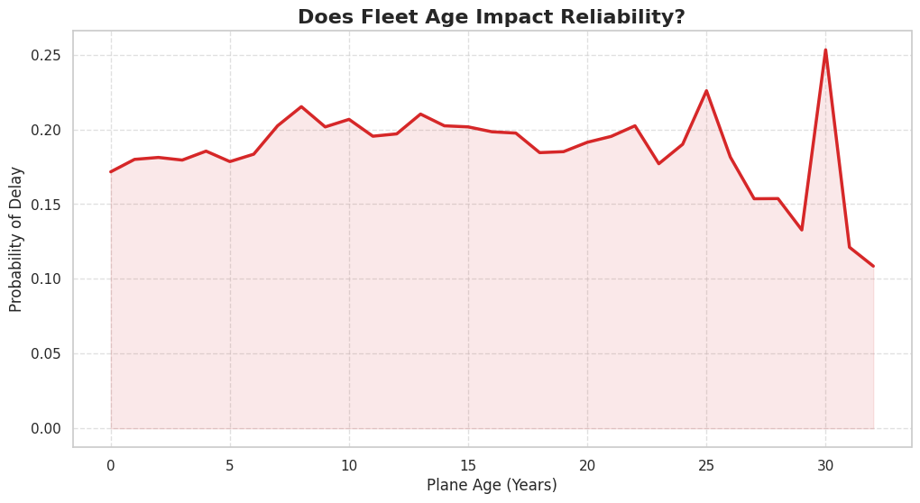

```python
# Group by Plane Age and calculate delay rate
age_delays = df.groupby('PLANE_AGE')['DEP_DEL15'].mean().reset_index()

# Filter out unreasonable ages (e.g., usually planes > 40-50 years are outliers or rare)
age_delays = age_delays[age_delays['PLANE_AGE'] <= 40]

plt.figure(figsize=(12, 6))
sns.lineplot(data=age_delays, x='PLANE_AGE', y='DEP_DEL15', linewidth=2.5, color='#d62728')
plt.fill_between(age_delays['PLANE_AGE'], age_delays['DEP_DEL15'], alpha=0.1, color='#d62728') # Add shading

plt.title('Does Fleet Age Impact Reliability?', fontsize=16, fontweight='bold')
plt.xlabel('Plane Age (Years)', fontsize=12)
plt.ylabel('Probability of Delay', fontsize=12)
plt.grid(True, linestyle='--', alpha=0.6)
plt.show()
```

## The "External Factor" – Weather (Snow/Rain)

Insight: How drastically does weather impact operations?

Visual: Comparing delay rates on snowy days vs non-snowy days.

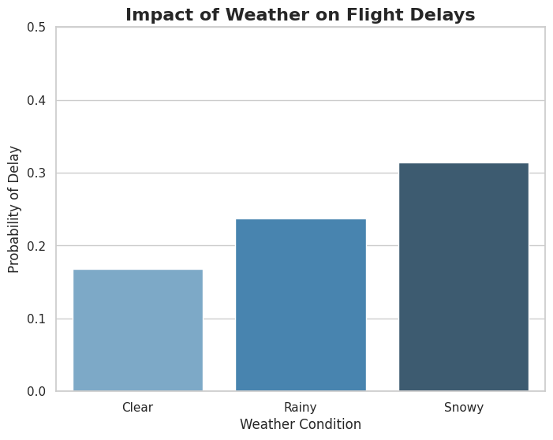

```python
# Create a simple category for "Bad Weather" vs "Good Weather"
# We'll use a threshold for PRCP (Precipitation) or SNOW
df['Weather_Condition'] = 'Clear'
df.loc[df['PRCP'] > 0, 'Weather_Condition'] = 'Rainy'
df.loc[df['SNOW'] > 0, 'Weather_Condition'] = 'Snowy'

# Calculate stats
weather_impact = df.groupby('Weather_Condition')['DEP_DEL15'].mean().reset_index()

# Plot
plt.figure(figsize=(8, 6))
sns.barplot(data=weather_impact, x='Weather_Condition', y='DEP_DEL15', palette="Blues_d", order=['Clear', 'Rainy', 'Snowy'])
plt.title('Impact of Weather on Flight Delays', fontsize=16, fontweight='bold')
plt.ylabel('Probability of Delay', fontsize=12)
plt.xlabel('Weather Condition', fontsize=12)
plt.ylim(0, 0.5) # Assuming delays don't exceed 50% avg, adjust if needed
plt.show()
```

## The "Hidden Patterns" – Correlation Heatmap

Comparing everything (Categorical + Numerical) to see what drives delays.

Insight: What variables actually drive delays?

Why this matters: This tells which features are redundant and which are important.

For example, if PRCP (Rain) has a higher correlation with DEP_DEL15 (Delay) than PLANE_AGE, you know weather is a stronger predictor than equipment.

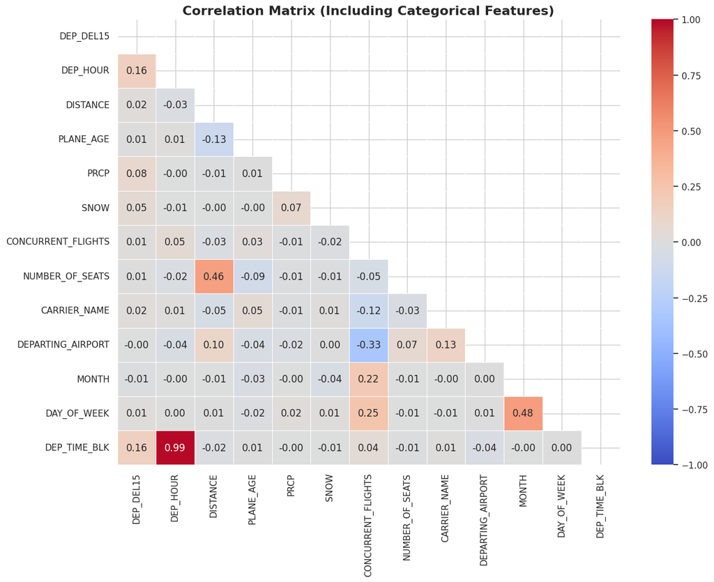

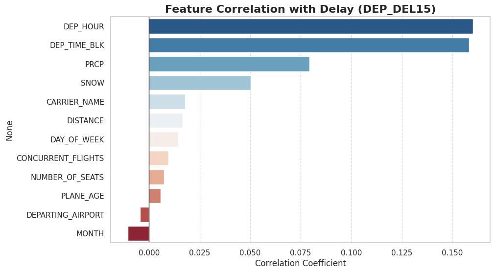

```python
# 1. Prepare data: Convert relevant categorical columns to numeric codes
# We create a copy so we don't mess up the original dataframe
df_corr = df.copy()

# List of categorical columns to include
cat_cols = ['CARRIER_NAME', 'DEPARTING_AIRPORT', 'MONTH', 'DAY_OF_WEEK', 'DEP_TIME_BLK']

# Convert them to codes (e.g., Delta -> 1, United -> 2)
for col in cat_cols:
    df_corr[col] = df_corr[col].astype('category').cat.codes

# 2. Select columns to correlate (Numerical + the newly encoded Categorical ones)
cols_to_analyze = ['DEP_DEL15', 'DEP_HOUR', 'DISTANCE', 'PLANE_AGE', 'PRCP', 'SNOW',
                   'CONCURRENT_FLIGHTS', 'NUMBER_OF_SEATS'] + cat_cols

# 3. Calculate Correlation
corr_matrix = df_corr[cols_to_analyze].corr()

# --- VISUAL 1: The Full Heatmap ---
plt.figure(figsize=(14, 10))
mask = np.triu(np.ones_like(corr_matrix, dtype=bool))
sns.heatmap(corr_matrix, mask=mask, annot=True, fmt=".2f", cmap='coolwarm',
            vmin=-1, vmax=1, center=0, linewidths=0.5)
plt.title('Correlation Matrix (Including Categorical Features)', fontsize=16, fontweight='bold')
plt.show()

# --- VISUAL 2: Ranked Feature Importance (Bar Chart) ---
# This is often clearer: "How much does X correlate with Delay?"
target_corr = corr_matrix['DEP_DEL15'].drop('DEP_DEL15').sort_values(ascending=False)

plt.figure(figsize=(10, 6))
sns.barplot(x=target_corr.values, y=target_corr.index, palette='RdBu_r')
plt.title('Feature Correlation with Delay (DEP_DEL15)', fontsize=16, fontweight='bold')
plt.xlabel('Correlation Coefficient', fontsize=12)
plt.axvline(0, color='black', linewidth=1) # Zero line
plt.grid(axis='x', linestyle='--', alpha=0.7)
plt.show()
```

## The "Where" – Geospatial Map of Busy Hubs

Insight: Which geographical locations are the biggest bottlenecks?

Why this matters: We can use the LATITUDE and LONGITUDE columns to plot airports.

```python
import plotly.express as px

# 1. Group by Airport
airport_stats = df.groupby(['DEPARTING_AIRPORT', 'LATITUDE', 'LONGITUDE']).agg(
    Flights=('DEP_DEL15', 'count'),
    Avg_Delay=('DEP_DEL15', 'mean')
).reset_index()

# 2. Round the Average Delay to 3 decimal places for clean display
airport_stats['Avg_Delay_Display'] = airport_stats['Avg_Delay'].round(3)

# 3. Filter to remove tiny airports if necessary (e.g., < 100 flights) to avoid outliers
# airport_stats = airport_stats[airport_stats['Flights'] > 100]

# --- PART A: Print Top 5 Worst Airports ---
top_5_delays = airport_stats.sort_values(by='Avg_Delay', ascending=False).head(5)
print("--- Top 5 Airports with Highest Average Delay ---")
display(top_5_delays[['DEPARTING_AIRPORT', 'Flights', 'Avg_Delay_Display']])

# --- PART B: Plot the Map ---
fig = px.scatter_geo(
    airport_stats,
    lat='LATITUDE',
    lon='LONGITUDE',
    hover_name='DEPARTING_AIRPORT',
    # We explicitly tell it to use the rounded column for the hover data
    hover_data={'LATITUDE': False, 'LONGITUDE': False, 'Flights': True, 'Avg_Delay_Display': True},
    size='Flights',
    color='Avg_Delay',
    color_continuous_scale='Reds',
    scope='usa',
    title='Airport Traffic Volume & Delay Intensity',
    projection='albers usa'
)

# Rename the label in the tooltip to look nice
fig.update_traces(hovertemplate='<b>%{hovertext}</b><br>Flights: %{marker.size}<br>Avg Delay: %{customdata[1]}')

fig.update_layout(title_font_size=20)
fig.show()
```

```
--- Top 5 Airports with Highest Average Delay ---
```

|  | DEPARTING_AIRPORT | Flights | Avg_Delay_Display |
| --- | --- | --- | --- |
| 6 | Aspen Pitkin County Sardy Field | 1242 | 0.324 |
| 120 | Westchester County | 1900 | 0.293 |
| 17 | Chicago Midway International | 86637 | 0.268 |
| 71 | Newark Liberty International | 143756 | 0.259 |
| 123 | William P Hobby | 62902 | 0.249 |

[interactive chart not shown]

## "Top 50" Airport Map

Insight: Where are the major hubs and how do they perform?

Visual: A static, publication-ready map showing the Top 50 busiest airports, colored by their average delay.

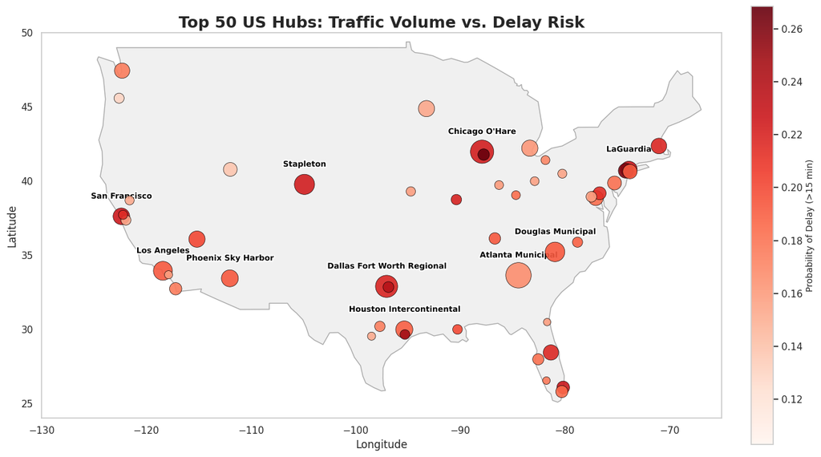

```python
# 1. Install Geopandas
!pip install geopandas -q

import geopandas as gpd
import matplotlib.pyplot as plt
import matplotlib.patheffects as pe # For the text halo

# 2. Prepare Data (Same aggregation as before)
airport_stats = df.groupby(['DEPARTING_AIRPORT', 'LATITUDE', 'LONGITUDE']).agg(
    Flights=('DEP_DEL15', 'count'),
    Avg_Delay=('DEP_DEL15', 'mean')
).reset_index()

# Filter for Top 50 Busiest Airports
top_50_airports = airport_stats.sort_values(by='Flights', ascending=False).head(50)

# 3. Load the Real Map (The FIX: Load directly from URL)
# We use the direct link to the Natural Earth shapefile
url = "https://naturalearth.s3.amazonaws.com/110m_cultural/ne_110m_admin_0_countries.zip"
world = gpd.read_file(url)

# Filter for USA (Note: 'ADMIN' is the standard column name in this dataset)
usa = world[world['ADMIN'] == "United States of America"]

# 4. Initialize the Plot
fig, ax = plt.subplots(figsize=(15, 10))

# --- LAYER 1: The Base Map ---
usa.plot(ax=ax, color='#f0f0f0', edgecolor='darkgrey', linewidth=1)

# --- LAYER 2: The Airport Bubbles ---
scatter = ax.scatter(
    top_50_airports['LONGITUDE'],
    top_50_airports['LATITUDE'],
    s=top_50_airports['Flights'] / 500,  # Adjust size scaling if needed
    c=top_50_airports['Avg_Delay'],      # Color by delay
    cmap='Reds',                         # Red = High Delay
    edgecolor='black',
    linewidth=0.5,
    alpha=0.9,
    zorder=5                             # Ensure dots are on TOP of the map
)

# --- LAYER 3: Labels for Top 10 Hubs ---
top_10 = top_50_airports.head(10)
for _, row in top_10.iterrows():
    # Clean the name for display
    clean_name = row['DEPARTING_AIRPORT'].replace(' International', '').replace(' Airport', '')

    ax.text(
        row['LONGITUDE'],
        row['LATITUDE'] + 1.2, # Push label slightly higher
        clean_name,
        fontsize=9,
        fontweight='bold',
        ha='center',
        color='black',
        path_effects=[pe.withStroke(linewidth=3, foreground="white")] # White halo
    )

# 5. Formatting & Zoom
# Zoom into Continental US
ax.set_xlim(-130, -65)
ax.set_ylim(24, 50)

# Add Colorbar
cbar = plt.colorbar(scatter, ax=ax, fraction=0.03, pad=0.04)
cbar.set_label('Probability of Delay (>15 min)', fontsize=10)

plt.title('Top 50 US Hubs: Traffic Volume vs. Delay Risk', fontsize=18, fontweight='bold')
plt.xlabel('Longitude')
plt.ylabel('Latitude')
plt.grid(False)

plt.show()
```

## Monthly Seasonality (Volume vs. Delay)

Insight: Are delays caused by holiday rushes?

Visual: A dual-axis chart. Bars = Number of Flights (Volume), Line = Delay Percentage.

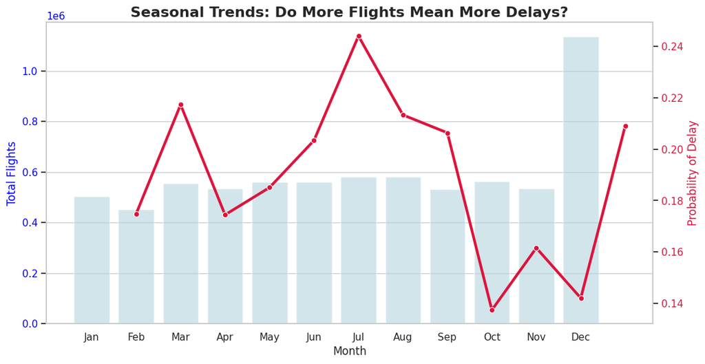

```python
# 1. Group by Month
monthly_stats = df.groupby('MONTH').agg(
    Flights=('DEP_DEL15', 'count'),
    Delay_Rate=('DEP_DEL15', 'mean')
).reset_index()

# 2. Setup the Plot (Dual Axis)
fig, ax1 = plt.subplots(figsize=(12, 6))

# Bar Plot for Volume (Left Axis)
sns.barplot(data=monthly_stats, x='MONTH', y='Flights', color='lightblue', alpha=0.6, ax=ax1)
ax1.set_ylabel('Total Flights', color='blue', fontsize=12)
ax1.tick_params(axis='y', labelcolor='blue')

# Line Plot for Delay Rate (Right Axis)
ax2 = ax1.twinx()
sns.lineplot(data=monthly_stats, x='MONTH', y='Delay_Rate', color='crimson', marker='o', linewidth=3, ax=ax2)
ax2.set_ylabel('Probability of Delay', color='crimson', fontsize=12)
ax2.tick_params(axis='y', labelcolor='crimson')

# 3. Formatting
# Force x-axis to be 1-12
ax1.set_xticks(range(12))
ax1.set_xticklabels(['Jan', 'Feb', 'Mar', 'Apr', 'May', 'Jun', 'Jul', 'Aug', 'Sep', 'Oct', 'Nov', 'Dec'])
ax1.set_xlabel('Month', fontsize=12)

plt.title('Seasonal Trends: Do More Flights Mean More Delays?', fontsize=16, fontweight='bold')
plt.grid(visible=False) # Turn off grid to keep dual-axis clean
plt.show()
```

#### What to look for:

If the Red Line (Delays) spikes in June/July/Dec while Blue Bars (Volume) are high, your inference is "Congestion drives delays."

If the Red Line spikes in Jan/Feb but Blue Bars are low, your inference is "Weather drives delays."

## Operational Resilience (Who Survives the Snow?)

Insight: Comparing airlines specifically during bad weather.

Visual: A grouped bar chart comparing Delay Rates during Clear days vs. Stormy days.

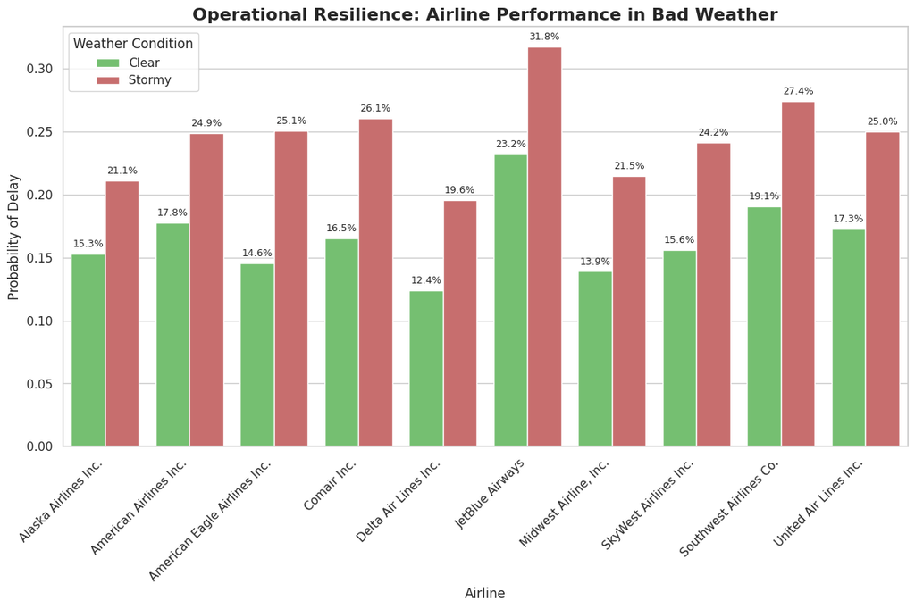

```python
# 1. Define "Stormy" (Rain > 0 or Snow > 0)
# You can adjust the threshold (e.g., > 0.1) if you want only severe storms
df['Condition'] = np.where((df['PRCP'] > 0) | (df['SNOW'] > 0), 'Stormy', 'Clear')

# 2. Select Top 10 Carriers (to keep chart readable)
top_carriers = df['CARRIER_NAME'].value_counts().head(10).index
subset_df = df[df['CARRIER_NAME'].isin(top_carriers)]

# 3. Group by Carrier and Condition
resilience = subset_df.groupby(['CARRIER_NAME', 'Condition'])['DEP_DEL15'].mean().reset_index()

# 4. Plot
plt.figure(figsize=(14, 7))
sns.barplot(data=resilience, x='CARRIER_NAME', y='DEP_DEL15', hue='Condition',
            palette={'Clear': 'g', 'Stormy': 'r'}) # Green for Clear, Red for Stormy

plt.title('Operational Resilience: Airline Performance in Bad Weather', fontsize=16, fontweight='bold')
plt.ylabel('Probability of Delay', fontsize=12)
plt.xlabel('Airline', fontsize=12)
plt.xticks(rotation=45, ha='right')
plt.legend(title='Weather Condition')

# Add values on top of bars
ax = plt.gca()
for p in ax.patches:
    if p.get_height() > 0: # Avoid labels on empty bars
        ax.annotate(f'{p.get_height():.1%}',
                    (p.get_x() + p.get_width() / 2., p.get_height()),
                    ha = 'center', va = 'center',
                    xytext = (0, 9),
                    textcoords = 'offset points', fontsize=9)

plt.show()
```

Small Gap: The airline has robust operations (they delay, but not much more than usual).

Huge Gap: The airline collapses when it rains/snows.

## The "Snowball Effect" (Why you should fly early)

Inference: Delays start low and peak at 6-7 PM.

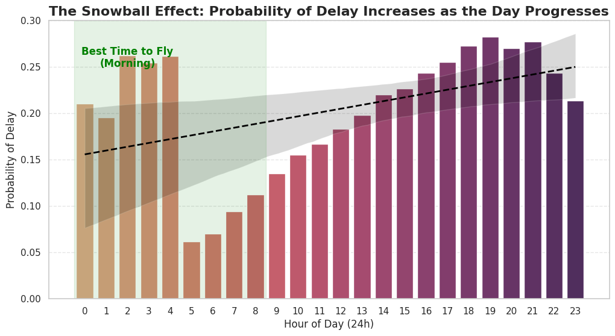

```python
# Group by scheduled departure hour
hourly_delay = df.groupby('DEP_HOUR')['DEP_DEL15'].mean().reset_index()

# Plot
plt.figure(figsize=(12, 6))
# Create a bar plot with a gradient color to show intensity
sns.barplot(data=hourly_delay, x='DEP_HOUR', y='DEP_DEL15', palette="flare")

# Add a trend line to show the "Snowball"
sns.regplot(data=hourly_delay, x='DEP_HOUR', y='DEP_DEL15', scatter=False, color='black', line_kws={"linewidth": 2, "linestyle": "--"})

plt.title('The Snowball Effect: Probability of Delay Increases as the Day Progresses', fontsize=16, fontweight='bold')
plt.xlabel('Hour of Day (24h)', fontsize=12)
plt.ylabel('Probability of Delay', fontsize=12)
plt.ylim(0, 0.3) # Adjust based on your data max
plt.grid(axis='y', linestyle='--', alpha=0.5)

# Annotation for the "Sweet Spot"
plt.axvspan(-0.5, 8.5, color='green', alpha=0.1)
plt.text(2, 0.25, 'Best Time to Fly\n(Morning)', color='green', fontweight='bold', ha='center')

plt.show()
```

## The "Wind Shear" Effect

Insight: Defines the exact wind speed where delays spike. It shows a smooth curve of how risk increases as wind gets stronger.

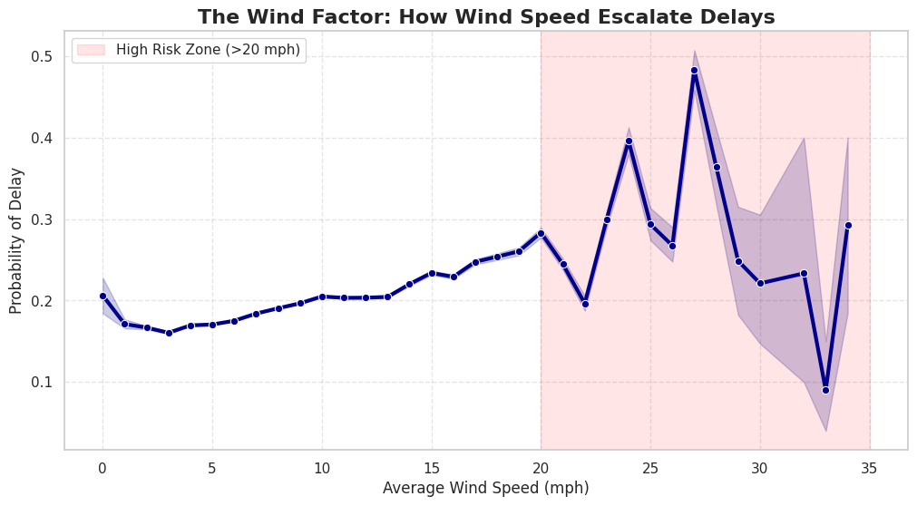

```python
# 1. Round Wind Speed to nearest integer to group data cleanly
df['Wind_Rounded'] = df['AWND'].round()

# 2. Filter out extreme outliers (e.g., hurricanes > 40mph) for a cleaner visual
# Most commercial ops stop well before this, so data becomes thin/noisy
wind_data = df[df['Wind_Rounded'] <= 35]

# 3. Plotting
plt.figure(figsize=(12, 6))

# Lineplot automatically calculates the Mean Delay (Probability) and adds a shadow (Confidence Interval)
sns.lineplot(data=wind_data, x='Wind_Rounded', y='DEP_DEL15',
             color='darkblue', linewidth=3, marker='o')

# 4. Add a "Danger Zone" background
plt.axvspan(20, 35, color='red', alpha=0.1, label='High Risk Zone (>20 mph)')

plt.title('The Wind Factor: How Wind Speed Escalate Delays', fontsize=16, fontweight='bold')
plt.xlabel('Average Wind Speed (mph)', fontsize=12)
plt.ylabel('Probability of Delay', fontsize=12)
plt.grid(True, linestyle='--', alpha=0.5)
plt.legend()

plt.show()
```

## The "Cursed Routes" (Top 10 Worst Flight Paths)

Insight: Which specific origin-destination pairs are consistently late? (e.g., "Chicago to New York").

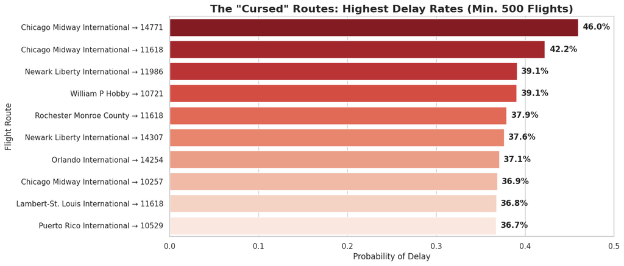

```python
# 1. Create a "Route" column
df['Route'] = df['DEPARTING_AIRPORT'] + " → " + df['DEST_AIRPORT_ID'].astype(str) # Using ID for Dest as name might not be cleaned
# If you have DEST_AIRPORT_NAME, swap it in above.

# 2. Group by Route
route_stats = df.groupby('Route').agg(
    Flights=('DEP_DEL15', 'count'),
    Delay_Rate=('DEP_DEL15', 'mean')
).reset_index()

# 3. Filter for routes with significant traffic (e.g., > 500 flights/year)
# This prevents a route with 1 flight that was late appearing as "100% delayed"
busy_routes = route_stats[route_stats['Flights'] > 500]

# 4. Get Top 10 Worst
worst_routes = busy_routes.sort_values(by='Delay_Rate', ascending=False).head(10)

# 5. Plot
plt.figure(figsize=(12, 6))
sns.barplot(data=worst_routes, x='Delay_Rate', y='Route', palette='Reds_r')

plt.title('The "Cursed" Routes: Highest Delay Rates (Min. 500 Flights)', fontsize=16, fontweight='bold')
plt.xlabel('Probability of Delay', fontsize=12)
plt.ylabel('Flight Route', fontsize=12)
plt.xlim(0, 0.5) # Adjust based on max delay
for i, v in enumerate(worst_routes['Delay_Rate']):
    plt.text(v + 0.005, i, f"{v:.1%}", va='center', fontweight='bold')

plt.show()
```

## Flight Distance vs. Delay (Short vs. Long Haul)

Inference: Are short "hopper" flights more unreliable than long-haul flights?

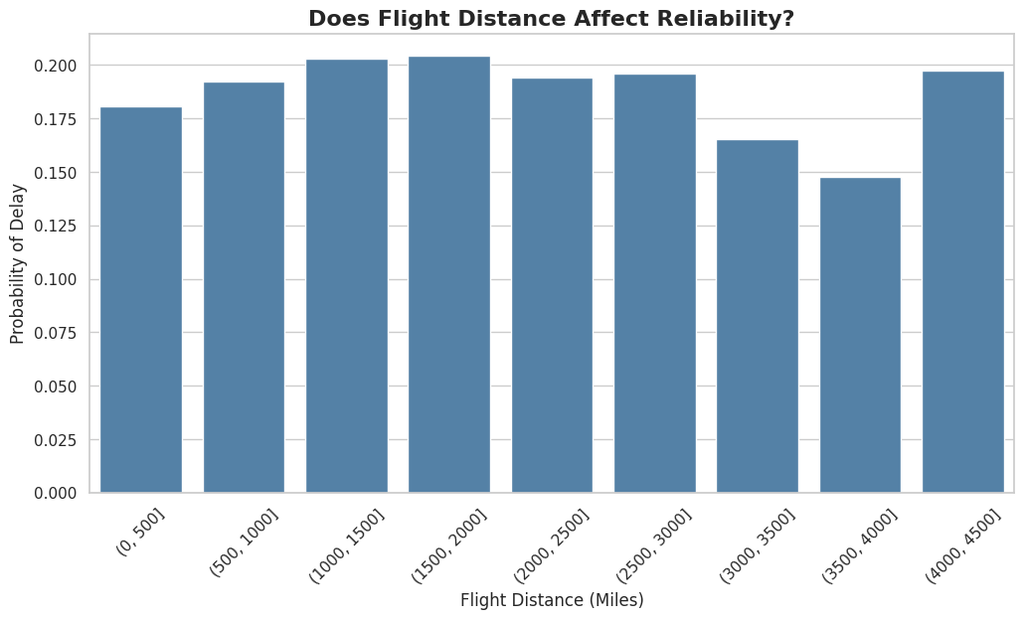

```python
# Create Distance Bins (e.g., 0-500 miles, 500-1000, etc.)
df['Dist_Bin'] = pd.cut(df['DISTANCE'], bins=range(0, 5000, 500))

# Calculate Delay % per bin
dist_delay = df.groupby('Dist_Bin')['DEP_DEL15'].mean().reset_index()

plt.figure(figsize=(12, 6))
sns.barplot(data=dist_delay, x='Dist_Bin', y='DEP_DEL15', color='steelblue')

plt.title('Does Flight Distance Affect Reliability?', fontsize=16, fontweight='bold')
plt.xlabel('Flight Distance (Miles)', fontsize=12)
plt.ylabel('Probability of Delay', fontsize=12)
plt.xticks(rotation=45)
plt.show()
```

## The "Distance Profile" (KDE Plot)

Insight: Do long-haul flights have a different delay profile than short-haul?

If the Red curve (Delays) shifts to the right, it visually proves that longer flights are riskier.

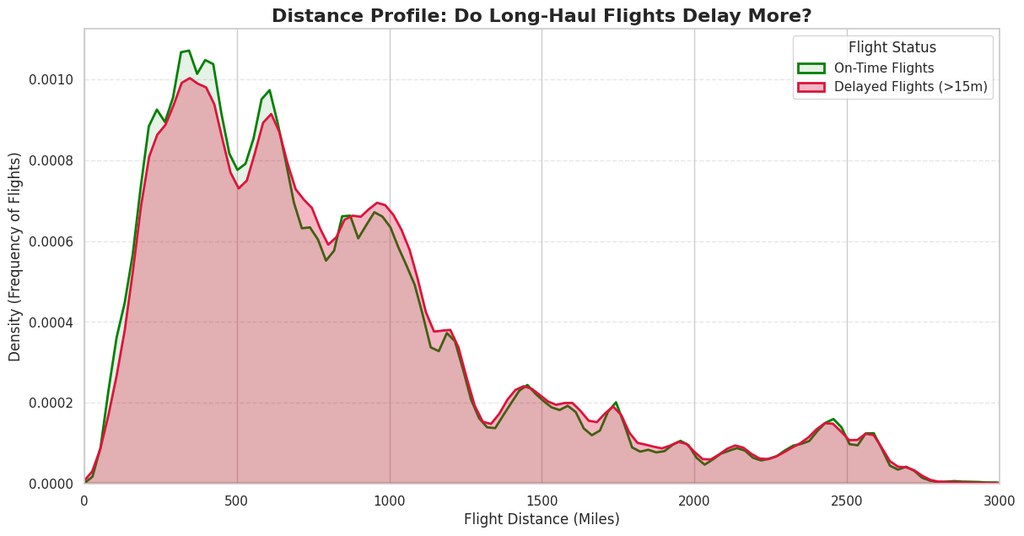

```python
# 1. Setup the Plot
plt.figure(figsize=(14, 7))

# 2. Draw the Density Curves
# We plot the distribution of DISTANCE for On-Time flights (Green)
sns.kdeplot(data=df[df['DEP_DEL15'] == 0], x='DISTANCE',
            fill=True, color='green', alpha=0.1, linewidth=2, label='On-Time Flights')

# We plot the distribution of DISTANCE for Delayed flights (Red)
sns.kdeplot(data=df[df['DEP_DEL15'] == 1], x='DISTANCE',
            fill=True, color='crimson', alpha=0.3, linewidth=2, label='Delayed Flights (>15m)')

# 3. Formatting
plt.title('Distance Profile: Do Long-Haul Flights Delay More?', fontsize=16, fontweight='bold')
plt.xlabel('Flight Distance (Miles)', fontsize=12)
plt.ylabel('Density (Frequency of Flights)', fontsize=12)
plt.grid(axis='y', linestyle='--', alpha=0.5)
plt.legend(title='Flight Status')

# Optional: Zoom in if you have mostly short flights (limits x-axis to 3000 miles)
plt.xlim(0, 3000)

plt.show()
```

### Conclusion: Exploratory Data Analysis of Flight Delays

This Exploratory Data Analysis (EDA) of over 7 million flight records confirms that delays are not random occurrences but are driven by predictable temporal, operational, and environmental factors. The analysis successfully identified the primary variables that will serve as the foundation for our predictive modeling phase.